# Momentum Strategy R-Project

Introduction to Data Science with R

Jawad KASSIMI

2025-04-07

# 1 General Introduction of the project

This project’s objective is to backtest a trading strategy using historical stock market data. While the implementation is the result of personal work, it draws inspiration from online resources and artificial intelligence tools to guide the development of the strategy. The study will compare a benchmark portfolio with a more advanced strategy that seeks to improve performance based on stock-specific signals.

I- Key Goals of my project :

- Implement a benchmark strategy: A simple equally weighted portfolio will be my reference.
- Develop an advanced trading strategy: Based on momentum and RSI filtering to optimize returns.
- Analyze performance metrics: Compute financial indicators such as annual return, volatility, Sharpe ratio, drawdown, and cumulative performance.
- Visualize portfolio performance: Generate several plots to assess strategy effectiveness.

II- The dataset I used consists of 88 stocks from the S&P 100 index retrieved from Yahoo Finance.

## 1.1 Installation and Loading of Required Packages

Before implementing the strategies, I need to load the necessary R libraries.

```r
library(quantmod)
library(PerformanceAnalytics)
library(ggplot2)
library(xts)
library(tidyverse)
library(dplyr)
library(tidyquant)
library(readxl)
library(plotly)
library(reshape2)
library(corrplot)
library(knitr)
library(kableExtra)
```

# 2 Selection of the assets

I took only 88 stocks to avoid issues when importing some past datas like for 2005, 2006 etc because stocks like Tesla or Meta were not existing.

## 2.1 List of the tickers

```r
# List of the 88 tickers from the SP100 index
symbols <- c("AAPL", "ABT", "ACN", "ADBE", "AIG", "AMD", "AMGN", "AMT", "AMZN",
             "AXP", "BA", "BAC", "BK", "BKNG", "BLK", "BMY", "BRK-B", "C", "CAT", "CL",
             "CMCSA", "COF", "COP", "COST", "CRM", "CSCO", "CVS", "CVX", "DE", "DHR", "DIS",
             "DUK", "EMR", "F", "FDX", "GD", "GE", "GILD", "GOOG", "GOOGL", "GS", "HD", "HON",
             "IBM", "INTC", "INTU", "JNJ", "JPM", "KO", "LIN", "LLY", "LMT", "LOW",
             "MCD", "MDLZ", "MDT", "MET", "MMM", "MO", "MRK", "MS", "MSFT", "NEE", "NFLX",
             "NKE", "NVDA", "ORCL", "PEP", "PFE", "PG", "QCOM", "RTX", "SBUX", "SCHW",
             "SO", "SPG", "T", "TGT", "TMO", "TXN", "UNH", "UNP", "UPS", "USB",
             "VZ", "WFC", "WMT", "XOM")
```

## 2.2 Creation of the portfolio and importation of the datas

The first step in my process is to retrieve historical stock prices from Yahoo Finance. Then, I structure this data into a time-series format for further analysis.

I- Key Steps in this chunk:

- Download historical stock prices from 2005 to 2025
- Extract adjusted closing prices for each ticker
- Merge all stock data into a structured time-series dataframe

```r
# Download stock data from Yahoo Finance
for (sym in symbols) {
  tryCatch({
    getSymbols(sym, src = "yahoo", from = "2005-01-01", to = "2025-01-01")
  }, error = function(e) {
    cat("Error while downloading for:", sym, "\n")
  })
}

# Extract adjusted closing prices for each stock
price_list <- lapply(symbols, function(sym) {
  if (exists(sym)) {
    return(Cl(get(sym)))
  } else {
    return(NULL)
  }
})
names(price_list) <- symbols #Assign stock tickers as column names

# Remove null elements (stocks that were not downloaded)
price_list <- price_list[!sapply(price_list, is.null)]

# Merge prices into a single dataframe
price_data <- do.call(merge, price_list)
colnames(price_data) <- names(price_list)

# Display the number of successfully imported stocks
cat("Number of stocks imported:", ncol(price_data), "\n")
```

```
## Number of stocks imported: 88
```

```r
# A Preview the first 5 columns of the dataset to check
head(price_data[, 1:min(5, ncol(price_data))])
```

```
##                AAPL      ABT   ACN   ADBE    AIG
## 2005-01-03 1.130179 22.39227 26.37 30.845 1320.6
## 2005-01-04 1.141786 22.16676 25.75 30.030 1325.0
## 2005-01-05 1.151786 21.91247 25.65 29.865 1347.0
## 2005-01-06 1.152679 22.40666 25.42 29.370 1349.2
## 2005-01-07 1.236607 22.79050 26.61 29.390 1351.6
## 2005-01-10 1.231429 23.01121 26.96 29.410 1354.0
```

# 3 Preliminary study of the portfolio

Before implementing my trading strategy, I first analyze some key characteristics of the top 10 stocks from my 88 selected assets. This will provide some insights into the composition of my portfolio and the relative importance of the major stocks.

## 3.1 Market Capitalization of the top 10

Market capitalization represents the total market value of a company’s outstanding shares. It gives a good idea of which companies dominate the market and how they can influence the overall portfolio. Also, companies with a higher market caps are generally more stable but offer a lower potential growth, whereas the smaller market cap ones are more volatile and so they are riskier.

The following code reads market capitalization data from an Excel file that I created, processes it, and visualizes the results.

I- Key Steps of the chunk:

- Read the Excel file containing market capitalization data.
- Convert values to trillions of USD.
- Visualize the companies in a horizontal bar chart.

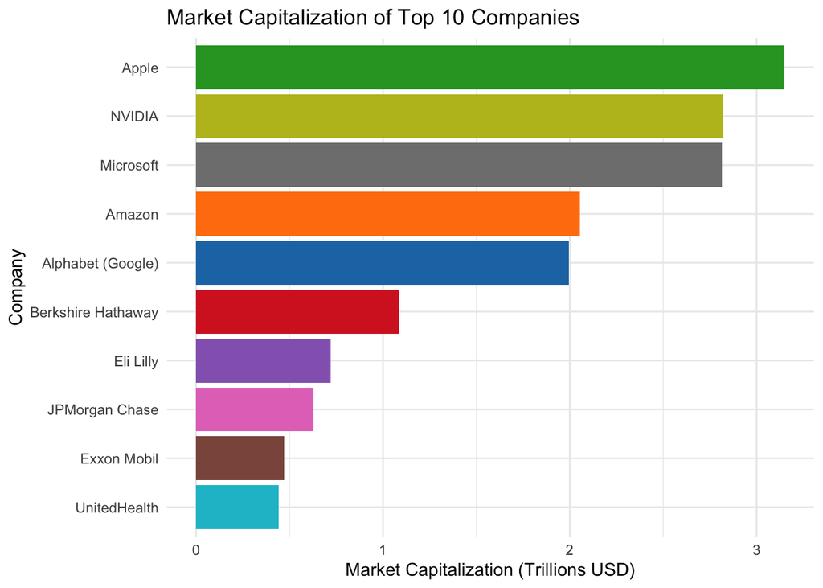

```r
# Load the Excel file
current_dir <- getwd() # Get the current working directory
file_path <- file.path(current_dir, "Market_Cap.xlsx") # Build the relative path to my Excel file
market_data <- read_excel(file_path) # Read the file

# Convert market cap to trillions (USD)
market_data <- market_data %>%
  mutate(marketcap = as.numeric(marketcap) / 1e12)  # Convert to trillions

# Horizontal bar plot
ggplot(market_data, aes(x = reorder(Name, marketcap), y = marketcap, fill = Name)) +
  geom_bar(stat = "identity", show.legend = FALSE) +
  coord_flip() +
  labs(title = "Market Capitalization of Top 10 Companies",
       x = "Company",
       y = "Market Capitalization (Trillions USD)") +
  theme_minimal() +
  scale_fill_manual(values = c("#1f77b4", "#ff7f0e", "#2ca02c", "#d62728",
                               "#9467bd", "#8c564b", "#e377c2", "#7f7f7f",
                               "#bcbd22", "#17becf"))
```

This chart provides a clear visualization of the relative market capitalization of the largest stocks in my portfolio. It shows the dominance of Apple, which stands as the largest company with a market cap exceeding $3 trillion. NVIDIA and Microsoft follow closely, highlighting the continued strength of the technology sector.

From a portfolio perspective, the dominance of technology stocks suggests strong growth potential, but it also means an increased volatility, especially during market downturns. While there is some presence of financial, healthcare, and energy stocks that helps mitigate risk and ensures some level of diversification, my portfolio still remains heavily weighted toward tech-driven performance.

## 3.2 Weight distribution of the top 10 companies

According to what we saw just before with the market cap I also wanted to analyze the weight distribution of the top 10.The goal is to understand the proportion of each stock in the portfolio and how their relative weight could impact the overall performance.

I created a pie chart that represents each company’s weight allocation in the portfolio.

I- Key Steps :

- Ensure proper formatting of weight data
- Generate the pie chart: I added labels to display percentages on each segment.

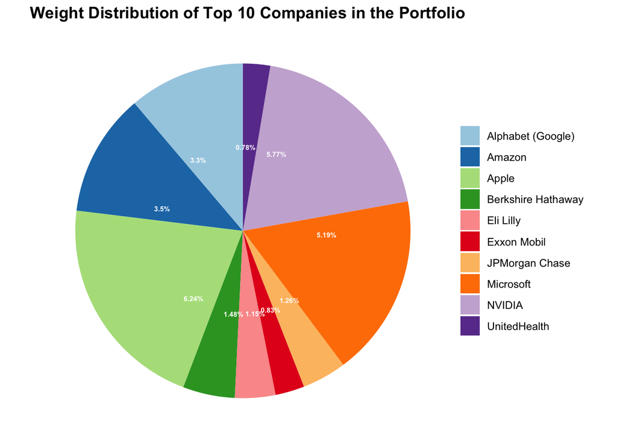

```r
# Ensure 'weight' is correctly formatted as a numeric percentage
market_data <- market_data %>%
  mutate(weight = as.numeric(gsub("%", "", weight)))

# Create the pie chart
ggplot(market_data, aes(x = "", y = weight, fill = Name)) +
  geom_bar(stat = "identity", width = 1) +
  coord_polar(theta = "y") +
  geom_text(aes(label = paste0(round(weight * 100, 2), "%")),
            position = position_stack(vjust = 0.2), size = 2, color = "white",
            fontface="bold") +  # Add labels
  scale_fill_brewer(palette = "Paired") +
  labs(title = "Weight Distribution of Top 10 Companies in the Portfolio") +
  theme_void() +  # Remove background grid
  theme(legend.title = element_blank(),
        plot.title = element_text(hjust = 0.2, face = "bold"))
```

We observe that Apple, NVIDIA, Microsoft, and Amazon hold the largest shares in the portfolio. Their weight confirms their dominance not only in terms of market capitalization but also in their overall influence on portfolio performance. Some other companies like Alphabet, Berkshire Hathaway, Eli Lilly, JPMorgan Chase, Exxon Mobil, and UnitedHealth introduces some diversification into the portfolio which can help reduce the risks.

## 3.3 Correlation Heatmap

```r
# Cumpute the daily returns
returns <- na.omit(ROC(price_data, type = "discrete"))
```

Understanding the correlation structure within a portfolio is important to assess diversification and risk exposure.Highly correlated stocks tend to move in the same direction, increasing the portfolio’s volatility, while low or negatively correlated assets can provide hedging opportunities.

Here I plot a heatmap that provides an intuitive representation of how stock returns interact with each other.

I- Key Steps :

- I use cor() to compute pairwise Pearson correlations of stock returns.
- Transform the matrix into a format suitable for visualization **melt() function**.
- Create a heatmap: Red represents negative correlation, indicating opposing movements between stocks. Green represents positive correlation, showing similar price movement. White represents zero correlation between the two stocks.

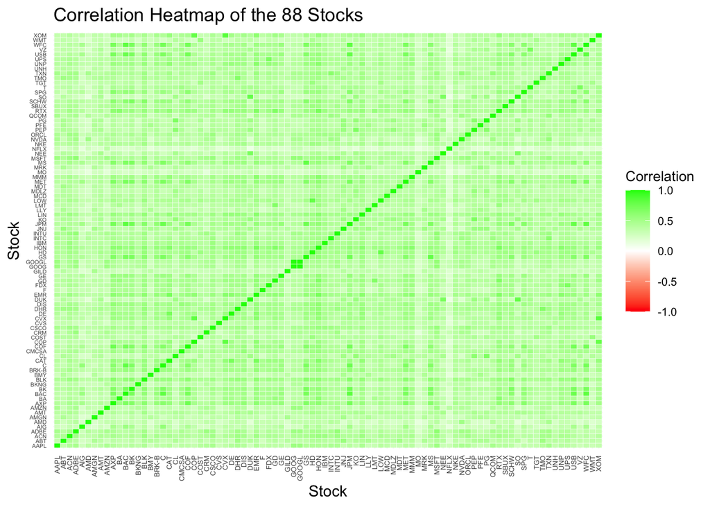

```r
# Compute correlation matrix
cor_matrix <- cor(returns, use = "pairwise.complete.obs")

# Convert matrix to long format for ggplot
melted_cor <- melt(cor_matrix)

# Plot heatmap with improved readability
ggplot(melted_cor, aes(x = Var1, y = Var2, fill = value)) +
  geom_tile(color = "white") +
  scale_fill_gradient2(low = "red", high = "green", mid = "white",
                       midpoint = 0, limit = c(-1,1), space = "Lab",
                       name="Correlation") +
  theme_minimal() +
  theme(
    axis.text.x = element_text(angle = 90, vjust = 0.5, hjust=1, size = 5),
    axis.text.y = element_text(size = 4),
    legend.title = element_text(size = 10),
    legend.text = element_text(size = 8)
  ) +
  labs(title = "Correlation Heatmap of the 88 Stocks",
       x = "Stock", y = "Stock")
```

# 4 Benchmark Strategy

The benchmark strategy serves as a reference point for evaluating the performance of the advanced trading strategy. I chose an equally weighted portfolio where each stock receives the same weight, regardless of the market capitalization.

## 4.1 Equally Weighted Portfolio

Key steps in the following code chunk:

I- Compute equal weights: Each stock receives a weight of 1/N, where N is the total number of stocks.  
II- Calculate portfolio returns: The overall return is computed as the weighted sum of individual stock returns.  
III- Compute key performance indicators:

- Annualized mean return: Measures the portfolio’s average yearly return.
- Annualized volatility: Reflects the risk level, calculated as the standard deviation of daily returns.
- Sharpe ratio: Evaluates risk-adjusted performance, showing how much return is gained per unit of risk.

```r
# Compute equal weights for each stock in the portfolio
n <- ncol(returns)
weights <- rep(1/n, n)

# Compute the portfolio returns
portfolio_returns <- Return.portfolio(R = returns, weights = weights)

# Compute key performance metrics
mean_return <- mean(portfolio_returns) * 252  # Annualized mean return
volatility <- sd(portfolio_returns) * sqrt(252)  # Annualized volatility
sharpe_ratio <- mean_return / volatility  # Sharpe ratio

# Create a dataframe to display the performance metrics
results <- data.frame(
  Metrics = c("Annualized Mean Return", "Annualized Volatility", "Sharpe Ratio"),
 Value = c(round(mean_return * 100, 2), round(volatility * 100, 2), round(sharpe_ratio, 2))
)
names(results)[2] <- "Value (%)"

kable(results, format = "html", caption = "Performance Metrics") %>%
  kable_styling(full_width = FALSE, bootstrap_options = c("striped", "hover", "condensed", "responsive")) %>%
  column_spec(1, bold = TRUE)
```

Performance Metrics

| Metrics | Value (%) |
| --- | --- |
| Annualized Mean Return | 18.86 |
| Annualized Volatility | 21.85 |
| Sharpe Ratio | 0.86 |

# 5 Results and charts

Then I calculated some essential metrics for visualizing the performance of the benchmark strategy.  
I- The cumulative returns showing the growth of an initial investment over time.  
II- The daily returns to analyze volatility and short-term fluctuations.  
III- The drawdowns to measure peak declines, highlighting periods of significant losses.

```r
# Computations of some metrics for the graphs
cumulative_returns <- cumprod(1 + portfolio_returns) - 1
daily_returns <- portfolio_returns
drawdown <- Drawdowns(portfolio_returns)
```

## 5.1 Charts 1/2

The first plot shows cumulative performance, illustrating portfolio growth over time. The line highlights trends, market crashes, or stagnation periods.

The second plot is a bar chart of daily returns, where green bars indicate positive returns and red bars represent negative returns. This helps visualize market volatility and identify periods of high fluctuations.

### 5.1.1 Cumulative Portfolio Performance

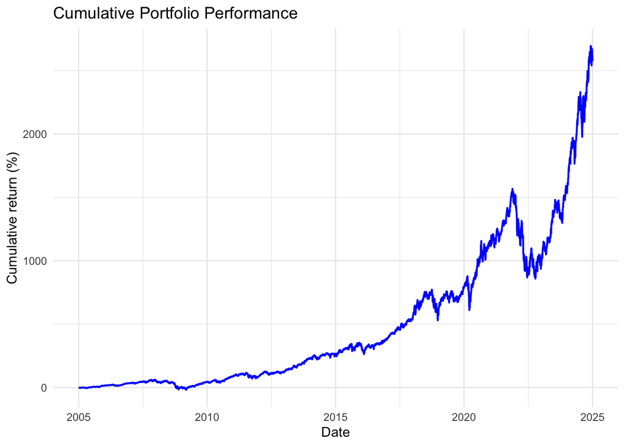

```r
# Cumulative portfolio performance graph
cumulative_returns_df <- data.frame(Date = index(cumulative_returns),
                                    Cumulative_Return = as.numeric(coredata(cumulative_returns)) * 100)

ggplot(cumulative_returns_df, aes(x = Date, y = Cumulative_Return)) +
  geom_line(color = "blue", linewidth = 0.7) +
  labs(title = "Cumulative Portfolio Performance",
       x = "Date", y = "Cumulative return (%)") +
  theme_minimal()
```

The strong upward trend indicates that the portfolio has consistently grown, reflecting the overall long-term appreciation of the stock market. However, some drawdowns can be observed, particularly around major market crises such as the COVID-19 crisis in 2020.

### 5.1.2 Portfolio’s Daily returns

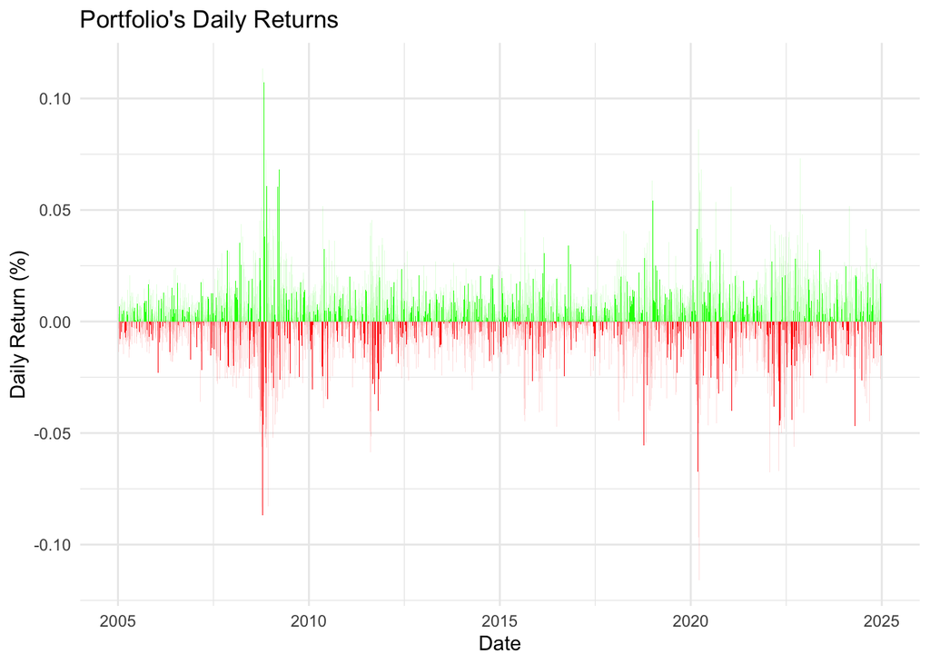

```r
# Daily returns bar chart
daily_returns_df <- data.frame(Date = index(daily_returns),
                               DailyReturn = coredata(daily_returns))

ggplot(daily_returns_df, aes(x = Date, y = daily_returns, fill = daily_returns > 0)) +
  geom_bar(stat = "identity", show.legend = FALSE) +
  scale_fill_manual(values = c("red", "green")) +
  labs(title = "Portfolio's Daily Returns",
       x = "Date", y = "Daily Return (%)") +
  theme_minimal()
```

We observe frequent fluctuations that indicate significant volatility, with occasional large spikes and drops corresponding to major market events. The presence of extreme downward movements highlights periods of high risk, reinforcing the importance of risk management.

## 5.2 Charts 2/2

Then I created two others charts to show the drawdowns and a histogram of the daily returns.

The first graph plots the drawdown over time, which measures the peak decline of the portfolio at any given point. A drawdown occurs when the portfolio value drops from a previous high, and this metric is important to measure the severity and duration of losses.

The histogram of daily returns shows the distribution of portfolio returns over time. The histogram provides insights into the volatility and skewness of returns. The red vertical dashed line represents the average return, showing whether the returns are normally distributed or exhibit extreme movements. A wider distribution indicates higher volatility, while a narrower concentration around the mean suggests stable performance.

### 5.2.1 Drawdown

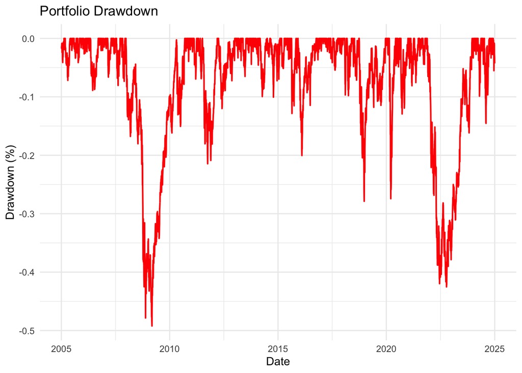

```r
# Drawdown plot
drawdown_df <- data.frame(Date = index(drawdown), drawdown = coredata(drawdown))

ggplot(drawdown_df, aes(x = Date, y = drawdown)) +
  geom_line(color = "red", linewidth = 0.7) +
  labs(title = "Portfolio Drawdown",
       x = "Date", y = "Drawdown (%)") +
  theme_minimal()
```

### 5.2.2 Histogram of daily returns

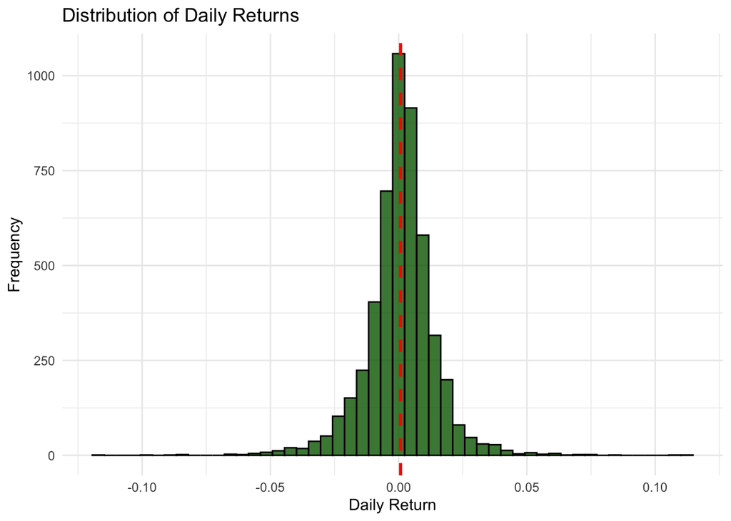

```r
# Histogram of daily returns
ggplot(data.frame(Returns = coredata(na.omit(portfolio_returns))), aes(x = portfolio_returns)) +
  geom_histogram(bins = 50, fill = "darkgreen", color = "black", alpha = 0.8) +
  geom_vline(xintercept = mean(portfolio_returns, na.rm = TRUE),
             color = "red", linetype = "dashed", linewidth = 1) +
  labs(title = "Distribution of Daily Returns",
       x = "Daily Return", y = "Frequency") +
  theme_minimal()
```

Thanks to this chart we can observe that the distribution is approximately normal, with most returns clustered around zero, meaning small daily changes are the most common. The red dashed line represents the mean daily return, which appears a bit positive. The fat tails on both sides indicate the occurrence of extreme market movements, showing that while the portfolio experiences small daily fluctuations most of the time, it is also subject to occasional large gains and losses, reinforcing the presence of market shocks and volatility spikes.

These four graphs provide a comprehensive view of the benchmark strategy’s risk-return dynamics, highlighting its steady long-term growth alongside periods of volatility and market stress. While the portfolio benefits from consistent appreciation, it still experiences significant drawdowns and daily fluctuations, highlighting the need for risk mitigation strategies.

# 6 Conclusion for the benchmark

So to sum up, the indicators show an average return of 18.86% and a Sharpe ratio of 0.86 for the egalitarian portfolio based on the 88 selected from the SP100 stocks. The portfolio demonstrates a long-term growth, with measurable volatility and drawdowns, that provides me a reference point for comparing the advanced strategy.

# 7 Momentum Strategy using the RSI filter

## 7.1 Introduction

This advanced strategy leverages momentum and an RSI filter to optimize stock selection and improve risk-adjusted returns. Unlike the equally weighted benchmark, which passively distributes capital across all stocks, my advanced strategy dynamically allocates investments by identifying high-momentum winners and low-momentum losers.

## 7.2 Liste des tickers

I keep the same 88 stocks choosen from the SP100 as for the benchmark strategy.

## 7.3 Get again the datas of the 88 stocks

Here, I create another list variable for the stocks as for the list just before (**momentum_symbols**). I already have done this step in the benchmark strategy to collect data for each stock but I wanted to redo everything with different variable names (typically I added **momentum_** in front of each variable to differentiate them) to be sure to avoid any mistakes and confusion while using the variables for the following parts of my code.

```r
for (sym in momentum_symbols) {
  tryCatch({
    getSymbols(sym, src = "yahoo", from = "2005-01-01", to = "2025-01-01")
  }, error = function(e) {
    cat("Error while downloading for:", sym, "\n")
  })
}

# Extract adjusted closing prices
momentum_price_list <- lapply(momentum_symbols, function(sym) {
  if (exists(sym)) {
    return(Cl(get(sym)))
  } else {
    return(NULL)
  }})
momentum_price_list <- momentum_price_list[!sapply(momentum_price_list, is.null)]

# Merge prices
momentum_price_data <- do.call(merge, momentum_price_list)
colnames(momentum_price_data) <- momentum_symbols[1:ncol(momentum_price_data)]

head(momentum_price_data[, 1:min(5, ncol(momentum_price_data))])
```

```
##                AAPL      ABT   ACN   ADBE    AIG
## 2005-01-03 1.130179 22.39227 26.37 30.845 1320.6
## 2005-01-04 1.141786 22.16676 25.75 30.030 1325.0
## 2005-01-05 1.151786 21.91247 25.65 29.865 1347.0
## 2005-01-06 1.152679 22.40666 25.42 29.370 1349.2
## 2005-01-07 1.236607 22.79050 26.61 29.390 1351.6
## 2005-01-10 1.231429 23.01121 26.96 29.410 1354.0
```

# 8 Momentum Calculation Over 6 Months

This code chunk computes the 6-month momentum for each stock in the portfolio, which serves as the first signal for selecting assets for long and short positions.

I- Momentum computation :  
The **apply()** function iterates over each stock’s price series in momentum_price_data. It calculates the percentage change over the last 126 trading days, using **x / lag(x, 126)**. If a stock has fewer than 126 data points, I chose to return NA to avoid incomplete calculations.

II- Extracting the latest momentum values:  
Since I am only interested in the most recent momentum score, **tail(momentum_scores, 1)** extracts the latest available values for each stock.

III- Selecting long and short stocks:  
Then, stocks are ranked based on their momentum scores.The top 30% of stocks with the highest momentum are selected for long positions. The bottom 30% of stocks with the lowest momentum are selected for short positions and they are finally displayed.

```r
# Compute 6-month returns (momentum)
momentum_scores <- apply(momentum_price_data, 2, function(x) {
  if (length(x) >= 126) {
    return((x / lag(x, 126)) - 1)
  } else {
    return(rep(NA, length(x)))
  }
})

momentum_scores <- tail(momentum_scores, 1)  # Latest momentum value for each stock
momentum_scores <- na.omit(as.data.frame(t(momentum_scores)))

# Select stocks for Long (Top 30%) and Short (Bottom 30%) positions
momentum_long_stocks <- rownames(momentum_scores)[momentum_scores[, 1] >= quantile(momentum_scores[, 1], 0.7)]
momentum_short_stocks <- rownames(momentum_scores)[momentum_scores[, 1] <= quantile(momentum_scores[, 1], 0.3)]

cat("Stocks to Long:", momentum_long_stocks, "\n")
```

```
## Stocks to Long: ACN AXP BK BKNG BLK BMY COF CRM CSCO DE GILD GS HD IBM LOW MCD MET MMM MS NFLX ORCL RTX SBUX SPG T USB WMT
```

```r
cat("Stocks to Short:", momentum_short_stocks, "\n")
```

```
## Stocks to Short: ADBE AIG AMD AMGN AMT BA CL COP CVS CVX DHR F FDX GD INTC INTU LLY MDLZ MRK MSFT PEP PFE QCOM TGT TXN UPS XOM
```

# 9 Adding the RSI filter

Then, after the first selection of stocks to long and short, this code enhances the momentum strategy by applying a Relative Strength Index (RSI) filter to refine stock selection. The RSI helps identify overbought and oversold conditions, preventing trades that could be at risk of a reversal.

I- Computing the RSI for each stock:  
The 14-day RSI is calculated using the RSI() function from the **TTR package**.The results are converted into an xts object with proper date indexing for time series analysis.

II- Filtering stocks based on RSI:  
For long positions, only stocks with RSI < 65 are selected, avoiding overbought stocks.For short positions, only stocks with RSI > 35 are considered, filtering out oversold stocks that could rebound. Then, the final list of filtered long and short positions is extracted from the previously selected momentum stocks.

```r
# Compute the RSI for each stock (I chose 14 days)
momentum_rsi_data <- apply(momentum_price_data, 2, function(x) RSI(x, n = 14))
momentum_rsi_data <- xts(momentum_rsi_data, order.by = index(momentum_price_data)) #Convert to time series
momentum_rsi_data <- na.omit(momentum_rsi_data)  # Remove initial NA values from RSI calculation

# Apply the RSI filter to refine stock selection
momentum_valid_long <- momentum_long_stocks[momentum_rsi_data[nrow(momentum_rsi_data), momentum_long_stocks] < 65]
momentum_valid_short <- momentum_short_stocks[momentum_rsi_data[nrow(momentum_rsi_data), momentum_short_stocks] > 35]

cat("Long Stocks with RSI < 65 :", momentum_valid_long, "\n")
```

```
## Long Stocks with RSI < 65 : ACN AXP BK BKNG BLK BMY COF CRM CSCO DE GILD GS HD IBM LOW MCD MET MMM MS NFLX ORCL RTX SBUX SPG T USB WMT
```

```r
cat("Short Stocks with RSI > 35 :", momentum_valid_short, "\n")
```

```
## Short Stocks with RSI > 35 : AIG BA CL COP CVX DHR F FDX INTC INTU LLY MRK MSFT PEP PFE QCOM TGT TXN UPS
```

## 9.1 Long-Short strategy based on Momentum

The following code chunk computes the portfolio returns and performance metrics for the momentum strategy with the RSI filter, following a similar structure to the benchmark computation done just before. The filtered long and short stocks are assigned weights proportional to the strength of their momentum signals, while maintaining balanced exposure between long and short positions.The portfolio returns are then computed using **Return.portfolio()**, applying the selected weights.  
Finally, key performance indicators are computed like for the benchmark : annualized mean return, volatility, Sharpe ratio, and maximum drawdown.

```r
# Compute daily returns for the selected stocks
momentum_returns <- na.omit(ROC(momentum_price_data, type = "discrete"))

# Compute new weights based on the strength of the momentum signal
momentum_filtered_scores <- momentum_scores[c(momentum_valid_long, momentum_valid_short), , drop = FALSE]

# Normalize weights for long positions
long_scores <- momentum_filtered_scores[momentum_valid_long, 1]
long_weights <- long_scores / sum(abs(long_scores))  # normalized by absolute value
long_weights <- as.numeric(long_weights)

# Normalize weights for short positions
short_scores <- momentum_filtered_scores[momentum_valid_short, 1]
short_weights <- -short_scores / sum(abs(short_scores))  # negative for shorts
short_weights <- as.numeric(short_weights)

# Combine long and short weights
momentum_weights <- c(long_weights, short_weights)

# Compute portfolio returns based on selected stocks and weights
momentum_portfolio_returns <- Return.portfolio(R = momentum_returns[, c(momentum_valid_long, momentum_valid_short)],weights = momentum_weights)

# Calculate key performance metrics
momentum_mean_return <- mean(momentum_portfolio_returns) * 252
momentum_volatility <- sd(momentum_portfolio_returns) * sqrt(252)
momentum_sharpe_ratio <- momentum_mean_return / momentum_volatility
momentum_max_drawdown <- maxDrawdown(momentum_portfolio_returns)

# Create a dataframe for the results
momentum_results <- data.frame(
  Metrics = c("Annualized Return after RSI filter", "Annualized Volatility", "Sharpe Ratio", "Maximum Drawdown"),
  Value = c(round(momentum_mean_return * 100, 2),
                  round(momentum_volatility * 100, 2),
                  round(momentum_sharpe_ratio, 2),
                  round(momentum_max_drawdown * 100, 2))
)

names(momentum_results)[2] <- "Value (%)"

# Generate a table to display results
kable(momentum_results, format = "html", caption = "Momentum Strategy Performance Metrics") %>%
  kable_styling(full_width = FALSE, bootstrap_options = c("striped", "hover", "condensed", "responsive")) %>%
  column_spec(1, bold = TRUE)
```

Momentum Strategy Performance Metrics

| Metrics | Value (%) |
| --- | --- |
| Annualized Return after RSI filter | 25.02 |
| Annualized Volatility | 34.05 |
| Sharpe Ratio | 0.73 |
| Maximum Drawdown | 71.03 |

# 10 Results and charts

## 10.1 Charts 1/2

Like for the benchmark, this code chunk calculates essential metrics for visualizing the performance of the strategy.

```r
# Compute key performance metrics for the Momentum strategy
momentum_cumulative_returns <- cumprod(1 + momentum_portfolio_returns) - 1
momentum_daily_returns <- momentum_portfolio_returns
momentum_drawdown <- Drawdowns(momentum_portfolio_returns)
```

Then, as I already did for the benchmark I plot here 4 graphs. The first plot shows cumulative performance,the second plot is a bar chart of daily returns, the third one plots the drawdown over time and the last one shows a histogram of daily returns.

### 10.1.1 Cumulative Portfolio Performance

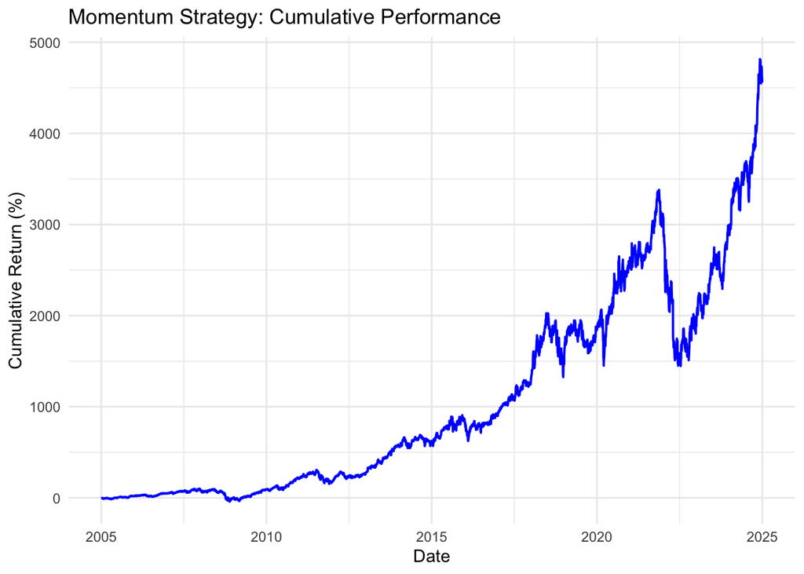

```r
# Cumulative Performance Graph
momentum_cumulative_returns_df <- data.frame(
  Date = index(momentum_cumulative_returns),
  Cumulative_Return = as.numeric(coredata(momentum_cumulative_returns)) * 100)

ggplot(momentum_cumulative_returns_df, aes(x = Date, y = Cumulative_Return)) +
  geom_line(color = "blue", linewidth = 0.7) +
  labs(title = "Momentum Strategy: Cumulative Performance",
       x = "Date", y = "Cumulative Return (%)") +
  theme_minimal()
```

### 10.1.2 Portfolio’s Daily Returns

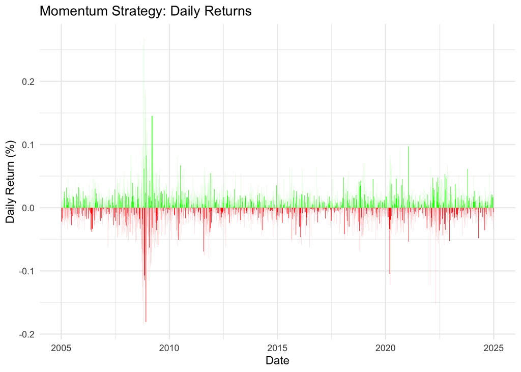

```r
# Daily Returns Bar Chart
momentum_daily_returns_df <- data.frame(Date = index(momentum_daily_returns),
  DailyReturn = coredata(momentum_daily_returns))

ggplot(momentum_daily_returns_df, aes(x = Date, y = momentum_daily_returns, fill = momentum_daily_returns > 0)) +
  geom_bar(stat = "identity", show.legend = FALSE) +
  scale_fill_manual(values = c("red", "green")) +
  labs(title = "Momentum Strategy: Daily Returns",
       x = "Date", y = "Daily Return (%)") +
  theme_minimal()
```

## 10.2 Charts 2/2

### 10.2.1 Drawdown

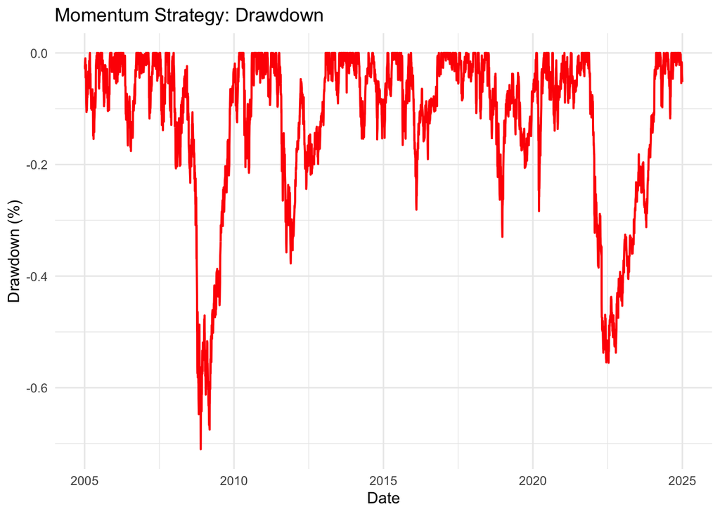

```r
# 3 Drawdown Graph
momentum_drawdown_df <- data.frame(Date = index(momentum_drawdown), Drawdown = coredata(momentum_drawdown))

ggplot(momentum_drawdown_df, aes(x = Date, y = momentum_drawdown)) +
  geom_line(color = "red", linewidth = 0.7) +
  labs(title = "Momentum Strategy: Drawdown",
       x = "Date", y = "Drawdown (%)") +
  theme_minimal()
```

### 10.2.2 Histogram of daily returns

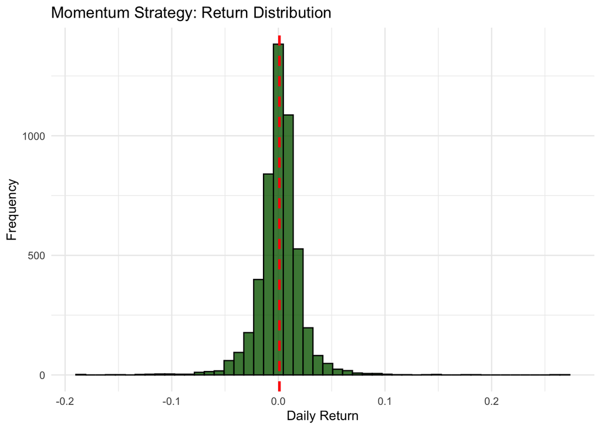

```r
# 4 Histogram of Daily Returns
ggplot(data.frame(Returns = coredata(na.omit(momentum_daily_returns))), aes(x = momentum_daily_returns)) +
  geom_histogram(bins = 50, fill = "darkgreen", color = "black", alpha = 0.8) +
  geom_vline(xintercept = mean(momentum_daily_returns, na.rm = TRUE),
             color = "red", linetype = "dashed", linewidth = 1) +
  labs(title = "Momentum Strategy: Return Distribution",
       x = "Daily Return", y = "Frequency") +
  theme_minimal()
```

As for the benchmark, here most returns cluster around zero, with a relatively narrow spread, but there are notable extreme values on both ends, indicating the presence of large positive and negative outliers. The red dashed line, representing the average return, is slightly positive, suggesting a favorable risk-reward profile over time. However, the long tails on both sides confirm that the strategy experiences occasional large gains and losses, reinforcing its high-risk and high-reward nature.

# 11 Comparison of the Benchmark and the Trading Strategy

Now I will compare the two strategies through plots.

The code below prepares the data for comparing the benchmark portfolio and the momentum strategy in terms of cumulative returns and drawdowns.A DataFrame is created to store cumulative performance of both the benchmark and momentum strategy over time and a second one is created to track drawdowns.

```r
# Create a DataFrame for cumulative returns comparison
comparison_cumulative_returns_df <- data.frame(Date = index(momentum_cumulative_returns),
  Benchmark_CumReturn = as.numeric(coredata(cumulative_returns)) * 100,
  Momentum_CumReturn = as.numeric(coredata(momentum_cumulative_returns)) * 100)

# Create a DataFrame for drawdown comparison
comparison_drawdown_df <- data.frame(Date = index(momentum_drawdown),
  Benchmark_Drawdown = as.numeric(coredata(drawdown)) * 100,
  Momentum_Drawdown = as.numeric(coredata(momentum_drawdown)) * 100)
```

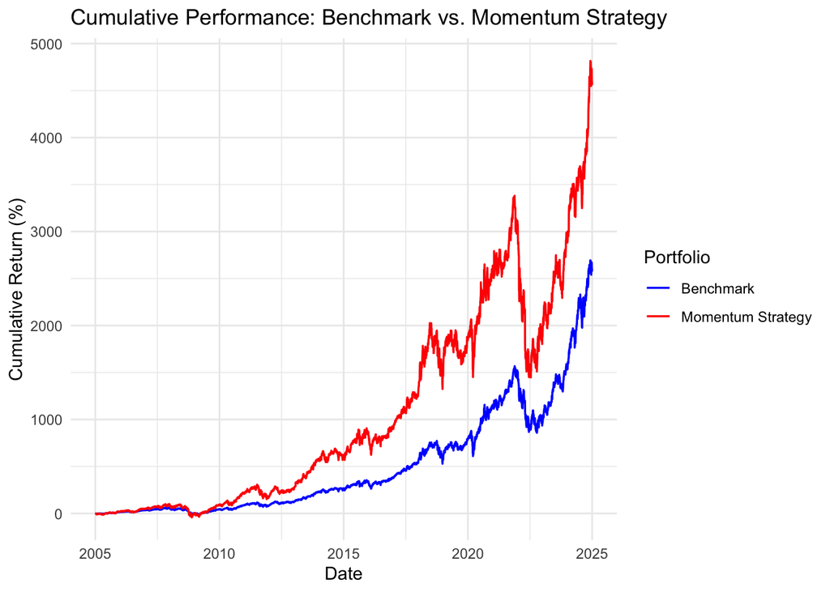

```r
# Benchmark vs. Momentum Strategy cumulative performance
ggplot(comparison_cumulative_returns_df, aes(x = Date)) +
  geom_line(aes(y = Benchmark_CumReturn, color = "Benchmark"), linewidth = 0.6) +
  geom_line(aes(y = Momentum_CumReturn, color = "Momentum Strategy"), linewidth = 0.6) +
  scale_color_manual(values = c("Benchmark" = "blue", "Momentum Strategy" = "red")) +
  labs(title = "Cumulative Performance: Benchmark vs. Momentum Strategy",
       x = "Date", y = "Cumulative Return (%)", color = "Portfolio") +
  theme_minimal()
```

I- Cumulative Performance Comparison

The momentum strategy generally outperforms the benchmark, showing higher returns across most periods. However, its volatility is also more pronounced, with sharper increases and declines. The significant divergence in recent years highlights how momentum-based stock selection has benefited from strong trends, whereas the benchmark follows a steadier growth path. So, despite some corrections, the momentum strategy has significantly outperformed the benchmark, delivering even higher cumulative returns due to the enhanced weighting on stronger signals.

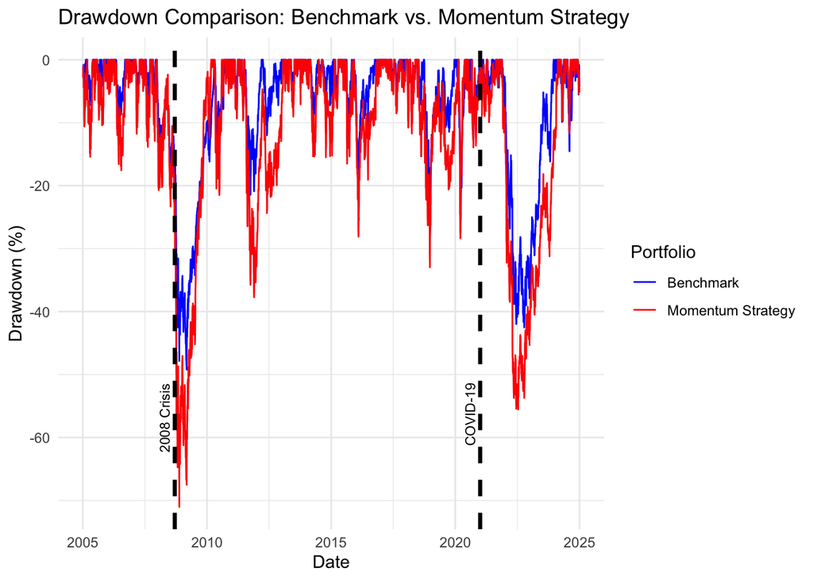

```r
# Crisis periods
crisis_dates <- as.Date(c("2008-09-15", "2021-01-01"))

# Benchmark vs. Momentum Strategy drawdown comparison
ggplot(comparison_drawdown_df, aes(x = Date)) +
  geom_line(aes(y = Benchmark_Drawdown, color = "Benchmark"), linewidth = 0.5) +
  geom_line(aes(y = Momentum_Drawdown, color = "Momentum Strategy"), linewidth = 0.5) +
  geom_vline(xintercept = as.numeric(crisis_dates[1]), linetype = "dashed", color = "black", linewidth = 1.2) +
  geom_vline(xintercept = as.numeric(crisis_dates[2]), linetype = "dashed", color = "black", linewidth = 1.2) +
  annotate("text", x = crisis_dates[1], y = min(comparison_drawdown_df$Benchmark, na.rm = TRUE),
           label = "2008 Crisis", angle = 90, vjust = -0.5, hjust = 1.2, size = 3, color = "black") +
  annotate("text", x = crisis_dates[2], y = min(comparison_drawdown_df$Benchmark, na.rm = TRUE),
           label = "COVID-19", angle = 90, vjust = -0.5, hjust = 1.2, size = 3, color = "black") +
  scale_color_manual(values = c("Benchmark" = "blue", "Momentum Strategy" = "red")) +
  labs(title = "Drawdown Comparison: Benchmark vs. Momentum Strategy",
       x = "Date", y = "Drawdown (%)", color = "Portfolio") +
  theme_minimal()
```

# 12 Conclusion

I compared my advanced momentum strategy, based on the past six-month performance and refined with an RSI filter and signal-weighted allocation, to an equally weighted benchmark portfolio. The results indicate that the momentum strategy achieves an annualized return of 25.02%, compared to 18.86% for the benchmark. However, this higher return comes at the cost of increased risk, with an annualized volatility of 34.05%, surpassing the benchmark’s 21.85%.

While the Sharpe ratio of the benchmark (0.86) is slightly higher than that of the momentum strategy (0.73), the difference remains minimal, suggesting that both portfolios offer similar risk-adjusted returns. However, a major distinction arises in maximum drawdown, where the momentum strategy suffers a peak loss of -71.03%, compared to the benchmark’s relatively lower drawdowns. This highlights the momentum strategy’s sensitivity to market downturns, making it more vulnerable to sharp reversals and increased drawdown risk.

From a performance perspective, the momentum approach has proven effective in capturing market trends and outperforming the benchmark over the long run. However, its higher volatility and deeper drawdowns suggest that risk management techniques could further improve the strategy, for instance incorporating stop-losses or dynamic position sizing to mitigate downside risks.